# useR2018! Recap and Highlights

August 16, 2018

## Overview

useR2018 was gReat!!

[figure not shown]

- [R Consortium Youtube Channel](https://www.youtube.com/channel/UC_R5smHVXRYGhZYDJsnXTwg/videos) has almost all talks and workshops posted
- We will cover the highlight here

## MGCV and GAMLSS tutorial- excellent

- GAMLSS (generalized additive models for location scale and shape)
- MGCV (GAM models and extensions - for bigger data than GAM package)
- Absolutely excellent tutorial you can watch [here](https://www.youtube.com/watch?v=a6sTwkQGt3E)
- Workshop content maybe the best part https://github.com/mfasiolo/workshop_UseR18
- Model fitting and evaluation
- Choosing the right smoothing parameters
- Great potential content for RLadies!

## gganimate keynote talk

- https://github.com/thomasp85
- Watch the talk [here](https://www.youtube.com/watch?v=21ZWDrTukEs&t=629s)
- Cool for learning gganimate - but cooler for hearing about how Thomas thinks of the relationship bewteen animated, static, and interactive visuals

## Glue Package (instead of paste!)

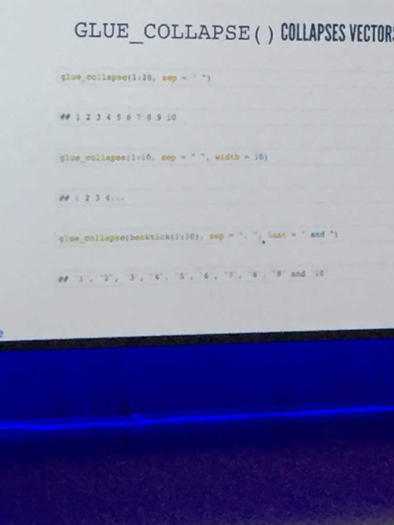

## Bill Venables: Adventures with R keynote

- What is the difference between a statistician and a data scientist?
- base vs tidyverse
- Watch talk [here](https://www.youtube.com/watch?v=XQmBcpQl8K8)

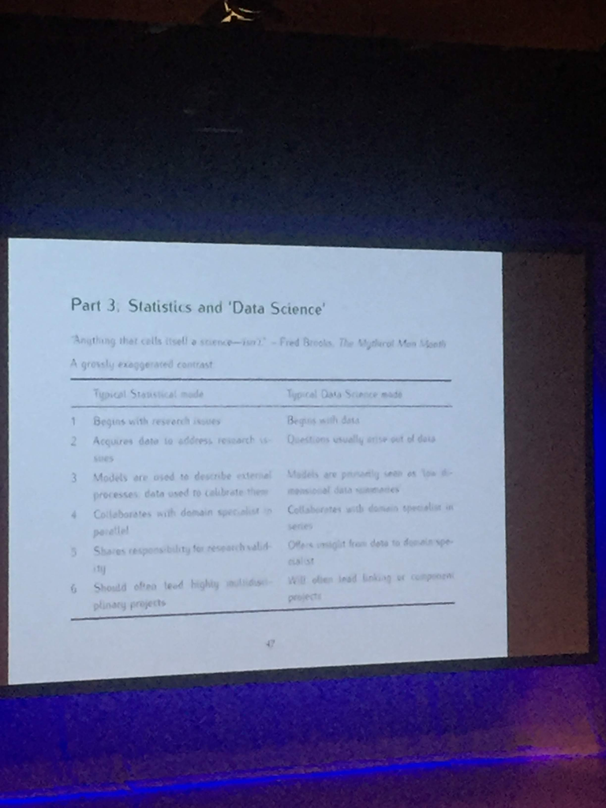

## Fasster package for Forecasting with Additive Switching of Seasonality, Trend, and Exogenous Regressors

- Package documentation and tutorial info https://github.com/tidyverts/fasster
- Allow for all sorts of features to be added to complicated forecasting models
  - Exogenous variables, or those not effecfted by other variables in the system or model
  - Can apply state space modeling techniques (i.e., type of pobabilisitic graphical modeling approach which uses information about the probabilistic dependence between the latent state variable and the observed measurement to help get a sense of the "expected")
- Multiple seasonaility in a state space modeling frameowkr
- Great for higher frequency time series data
- Would make a cool tutorial!
- Talk recording [here](https://www.youtube.com/watch?v=6YlboftSalY)

## Fable package: Displaying and analyzing univariate time series

- Package documentation and examples here https://github.com/tidyverts/fable
- Easy to apply smoothing via state state space and automatic ARIMA modeling approaches
- fits with the tidy verse
- Talk video [here](https://www.youtube.com/watch?v=MemnYSGeJ34)
  - Discusses the transition from the older forecast package to this newer package

## kwicRtopcs: HTML widget for displaying a Topic Model Browser

- Aides topic interpretation by highlighting words within the text and the topic for which they were most probable
- Materials and tutorials here https://github.com/aneesha/kwicRtopics
- Seems relatively out of the box for the end user
- Displays both top words and top topics

## Code Smells and Feels: Jenny Bryan Key note

- Awesome talk discussing why and when code "smells"
- Watch talk [here](https://www.youtube.com/watch?v=7oyiPBjLAWY)
- Excellent referesher on best practices in code writing
- Reminded me of a few functions
  - case_when
  - tryCatch
  - switch
  - %||% for value matching
- Based on refactoring book for java

## Roger Peng's talk

- Tidyverse, base, and all things evolution of R
- Watch talk [here](https://www.youtube.com/watch?v=5033jBHFiHE)

## Beyond Syntax: The Power of the open source community

- Watch talk [here](https://www.youtube.com/watch?v=27FxbDtCFoc)
- Awesome talk on all the comes with the R community and subculture